# Social-Network

Nicole Schlosberg

10/15/2020

# Social Network Analysis

## Part I

```r
D1 <- read.csv("comment-data.csv", header = TRUE)
#Each row represents a comment from one student to another so the first line shows that student "28" commented on the comment of student "21". It also shows the gender of both students and the students' main elective field of study ("major"").
```

Change the data type of the student id variable. Since it is a number R will automatically think it is an integer and code it as such (look at the list of variables by clicking on the data frame arrow in the Data pane. Here you will see the letters “int”" next to the stid variable, that stands for integer). However, in this case we are treating the variable as a category, there is no numeric meaning in the variable. So we need to change the format to be a category, what R calls a “factor”. We can do this with the following code:

```r
D1$comment.to <- as.factor(D1$comment.to)
D1$comment.from <- as.factor(D1$comment.from)
```

igraph requires data to be in a particular structure. There are several structures that it can use but we will be using a combination of an “edge list” and a “vertex list” in this assignment. As you might imagine the edge list contains a list of all the relationships between students and any characteristics of those edges that we might be interested in. There are two essential variables in the edge list a “from” variable and a “to” variable that descibe the relationships between vertices. While the vertex list contains all the characteristics of those vertices, in our case gender and major.

So let’s convert our data into an edge list!

First we will isolate the variables that are of interest: comment.from and comment.to

```r
library(dplyr)
D2 <- select(D1, comment.to, comment.from) #select() chooses the columns
```

Since our data represnts every time a student makes a comment there are multiple rows when the same student comments more than once on another student’s video. We want to collapse these into a single row, with a variable that shows how many times a student-student pair appears.

```r
#because igraph cant understand

EDGE <- count(D2, comment.to, comment.from) #count the rows of D2, and use both variables in the count

names(EDGE) <- c("to", "from","count")
```

EDGE is your edge list. Now we need to make the vertex list, a list of all the students and their characteristics in our network. Because there are some students who only recieve comments and do not give any we will need to combine the comment.from and comment.to variables to produce a complete list.

```r
#First we will separate the commenters from our commentees
V.FROM <- select(D1, comment.from, from.gender, from.major) #select all the froms together

#Now we will separate the commentees from our commenters
V.TO <- select(D1, comment.to, to.gender, to.major)

#Make sure that the from and to data frames have the same variables names bc want to stick them together and it needs to be the same all around
names(V.FROM) <- c("id", "gender.from", "major.from")
names(V.TO) <- c("id", "gender.to", "major.to")

#Make sure that the id variable in both dataframes has the same number of levels because we want to combine them (21 and 25 levels)
lvls <- sort(union(levels(V.FROM$id), levels(V.TO$id))) #union is like join but just for a vector

VERTEX <- full_join(mutate(V.FROM, id=factor(id, levels=lvls)),
    mutate(V.TO, id=factor(id, levels=lvls)), by = "id")

#Fill in missing gender and major values - ifelse() will convert factors to numerical values so convert to character
VERTEX$gender.from <- ifelse(is.na(VERTEX$gender.from) == TRUE, as.factor(as.character(VERTEX$gender.to)), as.factor(as.character(VERTEX$gender.from)))

VERTEX$major.from <- ifelse(is.na(VERTEX$major.from) == TRUE, as.factor(as.character(VERTEX$major.to)), as.factor(as.character(VERTEX$major.from)))
#ifelse doesnt convert nicely with factor

#Remove redundant gender and major variables
VERTEX <- select(VERTEX, id, gender.from, major.from)

#rename variables
names(VERTEX) <- c("id", "gender", "major")

#Remove all the repeats so that we just have a list of each student and their characteristics (unique()removes the duplicates)
VERTEX <- unique(VERTEX)
```

Now we have both a Vertex and Edge list it is time to plot our graph!

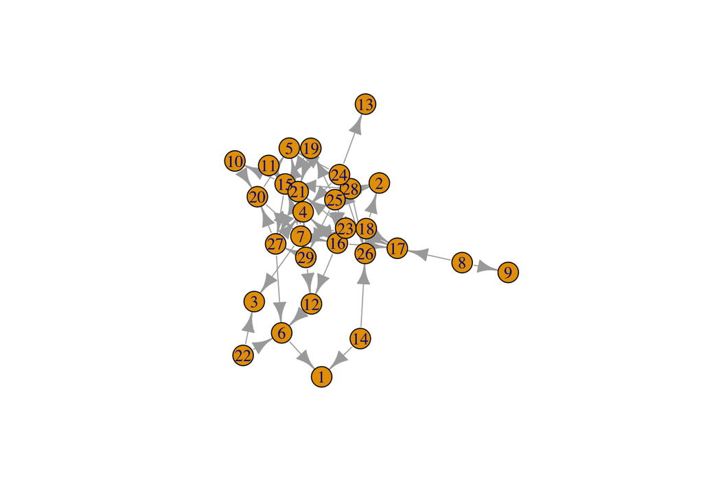

```r
library(igraph) #used to create igraph objects that have their own set of methods...
#First we will make an object that contains the graph information using our two dataframes EDGE and VERTEX. Notice that we have made "directed = TRUE" - our graph is directed since comments are being given from one student to another.

g <- graph.data.frame(EDGE, directed=TRUE, vertices=VERTEX)

#Now we can plot our graph using the force directed graphing technique - our old friend Fruchertman-Reingold! At a certain size these graphs look really bad so need to figure out a way to make it look better

plot(g,layout=layout.fruchterman.reingold)
```

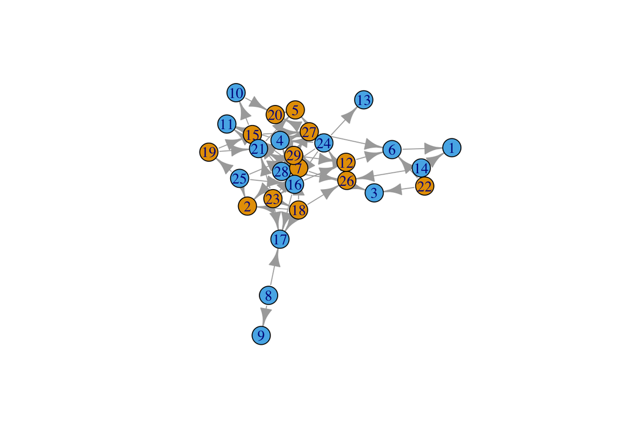

```r
#There are many ways to change the attributes of the graph to represent different characteristics of the newtork. For example, we can color the nodes according to gender.

plot(g,layout=layout.fruchterman.reingold, vertex.color=VERTEX$gender)
```

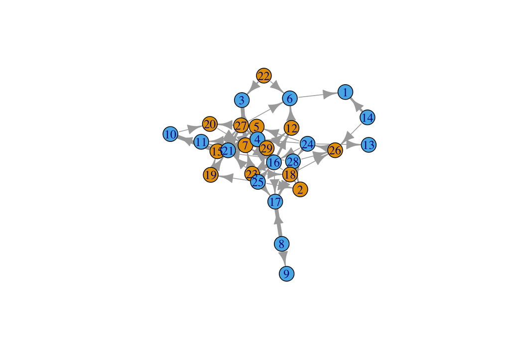

```r
#We can change the thickness of the edge according to the number of times a particular student has sent another student a comment.

plot(g,layout=layout.fruchterman.reingold, vertex.color=VERTEX$gender, edge.width=EDGE$count)
```

## Part II

Use [look up](http://igraph.org/r/) in the igraph documentation and modify the graph above so that:

or [look up](https://kateto.net/netscix2016.html)

- Ensure that sizing allows for an unobstructed view of the network features (For example, the arrow size is smaller)
- The vertices are colored according to major
- The vertices are sized according to the number of comments they have recieved

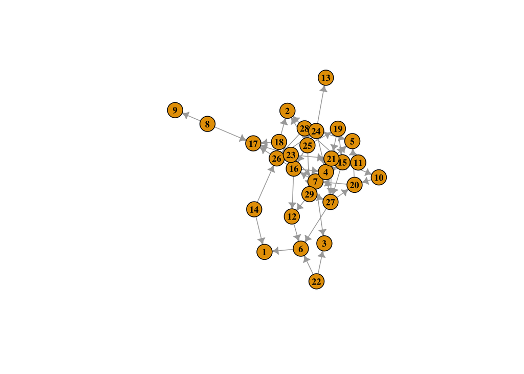

```r
library(igraph)
library(dplyr)

#Arrow size and other features
plot(g,layout=layout.fruchterman.reingold, edge.arrow.size=0.4,edge.arrow.width=2, vertex.label.cex=.75, vertex.label.color="black", vertex.label.font=2)
```

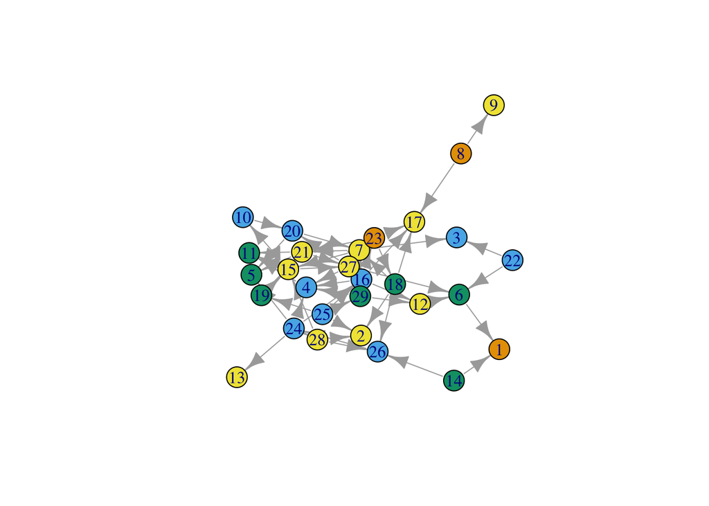

```r
#Vertices are colored by major
plot(g,layout=layout.fruchterman.reingold, vertex.color=VERTEX$major)
```

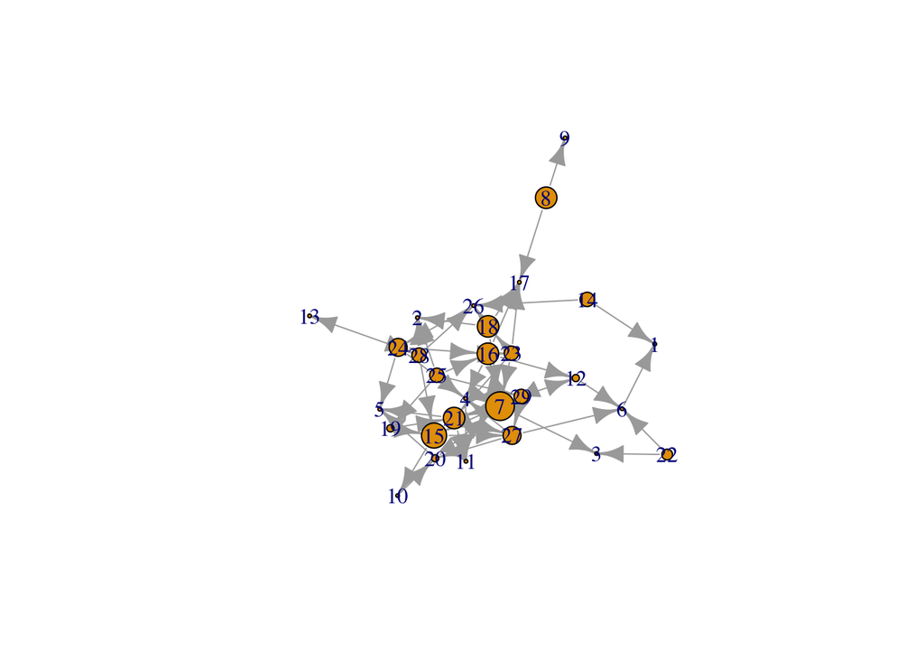

```r
#Vertices are sized by number of comments it received
S1 <- EDGE %>% group_by(to) %>% summarise(count = sum(count), .groups = "keep")
VERTEX <- left_join(VERTEX,S1, by=c("id"="to"))
VERTEX[is.na(VERTEX)] = 0
VERTEX$count <- as.integer(VERTEX$count)
plot(g,layout=layout.fruchterman.reingold, vertex.size=VERTEX$count*2)
```

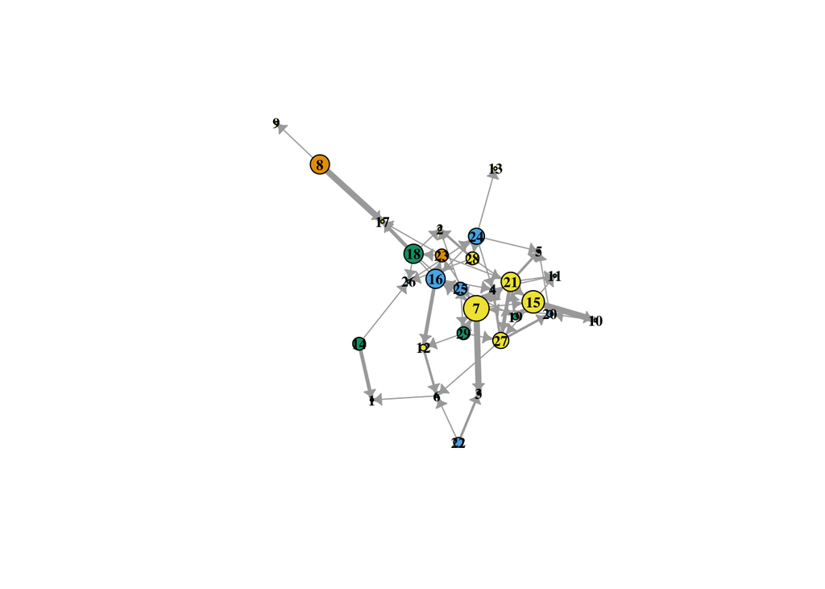

```r
#All steps together to modify the graph from Part I
plot(g, layout=layout.fruchterman.reingold, edge.width=EDGE$count, edge.arrow.size=0.4, edge.arrow.width=2,vertex.label.cex=0.75, vertex.label.color="black",vertex.label.font=2, vertex.color=VERTEX$major, vertex.size=VERTEX$count*2)
```

## Part III

Now practice with data from our class. This data is real class data directly exported from Qualtrics and you will need to wrangle it into shape before you can work with it. Import it into R as a data frame and look at it carefully to identify problems.

Create a **person-network** with the data set hudk4050-classes.csv. To create this network create a person-class matrix using the tidyr functions and then create a person-person matrix using `t()`, then plot a matrix rather than a to/from data frame using igraph.

Also [look up](http://igraph.org/r/) how to generate the following network metrics:

- Betweeness centrality and dregree centrality. **Who is the most central person in the network according to these two metrics? Write a sentence or two that describes your interpretation of these metrics**
- Color the nodes according to interest. Are there any clusters of interest that correspond to clusters in the network? Write a sentence or two describing your interpetation.

#Import data and tidy up the data

```r
library(dplyr)
library(tidyr)
library(stringr)

#read in file and create header names
S1 <- read.csv("hudk4050-classes.csv",col.names = c("First_Name", "Last_Name", "Class1", "Class2", "Class3", "Class4", "Class5", "Class6", "Topic_Interest"), stringsAsFactors = FALSE)
S2 <- S1
#remove unwanted rows
S2<-slice(S2,3:49)
#Fix names so that first and last are together as full name
S2 <- unite(S2,First_Name, Last_Name, col = "Full_Name", sep = " ", remove = TRUE)
#Get rid of random `
S2$Full_Name <- str_replace(S2$Full_Name, "`", "")
#Make all the names the same (capitals)
S2$Full_Name <- str_to_title(S2$Full_Name)
#Fix the class names so they are all the same (all caps)
S2 <- S2 %>% mutate_at(2:7, list(toupper))
#Fix the class names so they are all the same (no spaces)
S2 <- S2 %>% mutate_at(2:7, str_replace_all, " ", "")
S4 <- S2
```

#a.Create Person-Class matrix with tidyr; b. create Person-Person matrix with t()

```r
#a.
#Organize dataframe into the structure looking for
S3 <- gather(S2,2:7,key="counts",value="Class_Name", na.rm = TRUE, convert = FALSE) %>% select(Full_Name,Class_Name,counts)
#Danny Case
S3 <- S3[-c(42),]
#Creating a column of 1 that will be spread across the dataframe
S3$counts <- ifelse(S3$counts == "Class1", 1, ifelse(S3$counts == "Class2", 1, ifelse(S3$counts == "Class3", 1, ifelse(S3$counts == "Class4", 1, ifelse(S3$counts == "Class5", 1, ifelse(S3$counts == "Class6", 1, "NOPE"))))))
S3$counts <- as.numeric(S3$counts)
#Setting up NAs and removing them so does not interfer with spread()
S3$Class_Name <- ifelse(S3$Class_Name == "", NA, S3$Class_Name)
S3 <- na.omit(S3)
#Spreading the counts across the data frame with Class_Name across the top and leaving the student names
S3 <- spread(S3, Class_Name,counts)
#Putting 0 in place for NAs so that it is just a count of 1 and 0s
S3[is.na(S3)] <- 0
#Rename rows and picking columns to delete (deleting the names post row naming and to make the graph more interesting remove HUDK4050)
rownames(S3)<-S3$Full_Name
S3 <- select(S3, -Full_Name, -HUDK4050)
#Creates the Person-Class matrix
PersonClass <- as.matrix(S3)

#b. Create a person-person matrix using t()
ClassPerson <- t(PersonClass)
PersonPerson <- PersonClass %*% ClassPerson
```

#Plot Matrix using igraph

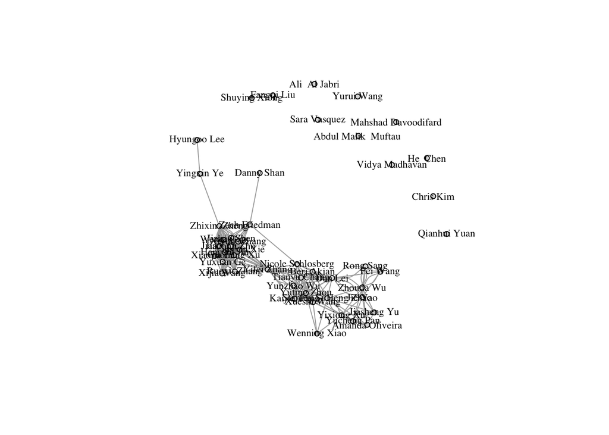

```r
library(igraph)
GraphedPersonPerson <- graph.adjacency(PersonPerson, mode = "undirected",diag = FALSE)
plot(GraphedPersonPerson, layout=layout.fruchterman.reingold,
     vertex.size = 4,
     vertex.label.cex=.7,
     vertex.label.color="black",
     vertex.color="gainsboro")
```

#Centrality

```r
#a. Betweeness Centrality
sort(betweenness(GraphedPersonPerson),decreasing=TRUE)
```

```
##          Yifei Zhang Stanley Si Heng Zhao              Dan Lei
##          260.6143603           97.2791152           83.4785714
##        Zhixin  Zheng        Zach Friedman    Nicole Schlosberg
##           66.2352941           43.3856397           36.6078619
##           Yingxin Ye          Xueshi Wang          Yuting Zhou
##           34.0000000           24.1453512           19.7898193
##            Zhouda Wu          Guoliang Xu          Hangshi Jin
##            8.9230159            7.5944061            7.5944061
##            Jiaao  Qi          Jiacong Zhu          Jiahao Shen
##            7.5944061            7.5944061            7.5944061
##            Wenqi Gao         Xiyun  Zhang          Yingxin Xie
##            7.5944061            7.5944061            7.5944061
##           Yixiong Xu              Jie Yao          Xiaojia Liu
##            5.0523810            4.4984127            3.2007978
##            Yuxuan Ge          Yucheng Pan Abdul Malik  Muftau
##            3.2007978            0.8333333            0.0000000
##        Ali  Al Jabri      Amanda Oliveira           Berj Akian
##            0.0000000            0.0000000            0.0000000
##            Chris Kim           Danny Shan           Fangqi Liu
##            0.0000000            0.0000000            0.0000000
##             Fei Wang             He  Chen          Hyungoo Lee
##            0.0000000            0.0000000            0.0000000
##          Jiasheng Yu         Kaijie  Fang  Mahshad Davoodifard
##            0.0000000            0.0000000            0.0000000
##         Qianhui Yuan            Rong Sang         Ruoyi  Zhang
##            0.0000000            0.0000000            0.0000000
##         Sara Vasquez        Shuying Xiong         Tianyu Chang
##            0.0000000            0.0000000            0.0000000
##       Vidya Madhavan         Wenning Xiao           Xijia Wang
##            0.0000000            0.0000000            0.0000000
##           Yunzhao Wu           Yurui Wang
##            0.0000000            0.0000000
```

```r
#b. Degree Centrality
sort(degree(GraphedPersonPerson),decreasing=TRUE)
```

```
##          Guoliang Xu          Hangshi Jin            Jiaao  Qi
##                   31                   31                   31
##          Jiacong Zhu          Jiahao Shen            Wenqi Gao
##                   31                   31                   31
##         Xiyun  Zhang          Yingxin Xie          Yifei Zhang
##                   31                   31                   24
##          Xiaojia Liu            Yuxuan Ge        Zhixin  Zheng
##                   22                   22                   20
## Stanley Si Heng Zhao              Dan Lei          Yuting Zhou
##                   19                   16                   16
##          Xueshi Wang            Zhouda Wu         Ruoyi  Zhang
##                   14                   14                   12
##         Tianyu Chang           Xijia Wang           Yunzhao Wu
##                   12                   12                   12
##              Jie Yao        Zach Friedman    Nicole Schlosberg
##                   11                   11                   10
##           Yixiong Xu           Berj Akian         Kaijie  Fang
##                   10                    9                    9
##            Rong Sang          Yucheng Pan      Amanda Oliveira
##                    8                    7                    6
##             Fei Wang          Jiasheng Yu         Wenning Xiao
##                    6                    6                    4
##           Yingxin Ye           Danny Shan           Fangqi Liu
##                    2                    1                    1
##          Hyungoo Lee        Shuying Xiong Abdul Malik  Muftau
##                    1                    1                    0
##        Ali  Al Jabri            Chris Kim             He  Chen
##                    0                    0                    0
##  Mahshad Davoodifard         Qianhui Yuan         Sara Vasquez
##                    0                    0                    0
##       Vidya Madhavan           Yurui Wang
##                    0                    0
```

```r
#Who is the most central person in the network according to these two metrics? Write a sentence or two that describes your interpretation of these metrics
# Yifei Zhang is the posible the most central as she connects groups so her betweenness is high, but because her her degree of centrality is not the highest she is not necessarily the most central. However, as her degree of centrality is rather high compared to the group and her betweenness is the highest, I will say she is the most central. She would be someone who could unite people in the class for a common goal.
```

#Color nodes by interest

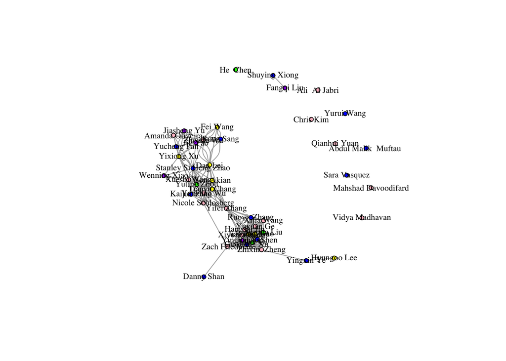

```r
S4 <- S4[order(S4$Full_Name),]
plot(GraphedPersonPerson, layout=layout.fruchterman.reingold,
     vertex.size = 4,
     vertex.label.cex=.7,
     vertex.label.color="black",
     vertex.color= ifelse(S4$Topic_Interest == "Prediction modelling", c( "pink"), ifelse(S4$Topic_Interest == "Visualization", c("yellow"), ifelse(S4$Topic_Interest == "Social Network Analysis", c( "blue"), ifelse(S4$Topic_Interest == "Facial recognition", c("green"), ifelse(S4$Topic_Interest == "Data Wrangling", c("purple"),c("black")))))))
```

```r
#Are there any clusters of interest that correspond to clusters in the network? Write a sentence or two describing your interpetation.
#There does not seem to be any clusters. However, you can see that there are few people who want to learn Visualization. Also a couple people who connect clusters are interested in prediction modelling. I would guess those who were not in many of the same classes, would be interested in something different than the others, but it seems that the interests do not congrigate by classes.
```